# Differential Expression Across pCO2 Treatments

Erin Chille

Last updated 2021/02/17

# BSF Biomineralization Project

## RNAseq Differential Expression Analysis

### Set up workspace

Load libraries

```r
library("genefilter")
library("DESeq2")
library("factoextra")
library("NbClust")
library("ComplexHeatmap")
library("tidyverse")
library("RColorBrewer")
library("ggplot2")
library("goseq")
library("gridExtra")
library("VennDiagram")
library("patchwork")
```

Import the data files

```r
#treatment information
treatmentinfo <- read.csv("Sample_Info/RNAseq_data.csv", header = TRUE, sep = ",")
str(treatmentinfo)
```

```
## 'data.frame':    44 obs. of  4 variables:
##  $ sample_id       : chr  "X119" "X120" "X121" "X127" ...
##  $ time_point      : chr  "Unfertilized_egg" "Unfertilized_egg" "Unfertilized_egg" "Fertilized_egg" ...
##  $ treatment       : chr  "amb" "amb" "amb" "amb" ...
##  $ extraction_batch: int  0 0 12 10 11 10 8 11 10 9 ...
```

```r
head(treatmentinfo)
```

```
##   sample_id       time_point treatment extraction_batch
## 1      X119 Unfertilized_egg       amb                0
## 2      X120 Unfertilized_egg       amb                0
## 3      X121 Unfertilized_egg       amb               12
## 4      X127   Fertilized_egg       amb               10
## 5      X128   Fertilized_egg         l               11
## 6      X129   Fertilized_egg        xl               10
```

```r
#gene count matrix
gcount <- as.data.frame(read.csv("2-QC-Align-Assemble/Output/gene_count_matrix.csv", row.names="gene_id"))
gcount <- gcount[ ,treatmentinfo$sample_id] #remove samples not in the treatment information csv (i.e. not in experiment)
dim(gcount)
```

```
## [1] 63227    44
```

```r
head(gcount)
```

```
##                    X119 X120 X121 X127 X128 X129 X130 X131 X132 X133 X134 X153
## g16981                0    0   11    0   22    0    0    0    0    0    0    0
## g16980                0    0    0    0    0    0    0    0    0    0    0    0
## g16983                0    0    0    0    0    0    0    0    0    0    0    0
## adi2mcaRNA10886_R1    0    0    0    0    0    0    0    0    0    0    0    0
## g16985                0    0    0    0    0    0    0    0    0    0    0    0
## g16984                0    0    0    0    0    0    0    0    0    0    0    0
##                    X154 X155 X156 X157 X158 X159 X160 X162 X163 X164 X165 X166
## g16981                0    0    0   22    0   50   53   31   25    0   45   35
## g16980                0    0    0    0    0    0    0    0    0    0    0    0
## g16983                0    0    0    0    0    0    0    0    0    0    0    2
## adi2mcaRNA10886_R1    0    0    0    0    0    0    0    8    0    0    0   15
## g16985                0    0    0    0    0    0    0    0    0    0    0    0
## g16984                0    0    0    4    0    0    0    0    0    0    0    0
##                    X167 X168 X169 X179 X180 X181 X182 X183 X184 X185 X186 X359
## g16981                0   40   10   15   11    0    0   13   26    0    0   28
## g16980                0    0    0    0    0    0    0    0    0    0    0    0
## g16983                4    4    0    0    0    0    0    0    0    0    3    0
## adi2mcaRNA10886_R1    0    3    0    0    0    0    0    0    0    0    0    0
## g16985                0    0    0    0    0    0    0    0    0    0    0   16
## g16984                0    0    0    0    0    0    0    0    0    0    0    4
##                    X361 X363 X365 X367 X371 X373 X375 X379
## g16981               28   33  100   16   81   24  180   30
## g16980                0    4    0    4    0    0    0    3
## g16983                0    0    0    0    0    0    1    2
## adi2mcaRNA10886_R1   14    6    0   14    0    0    0    5
## g16985                2    3    0    0    1    4   10    4
## g16984               14   19   36    9   21   19   15   11
```

### Fertilized embryo analysis

#### Construct DESeq2 dataset

##### Pre-filter gene counts

Pre-filtering our dataset to reduce the memory size dataframe, increase the speed of the transformation and testing functions, and improve quality of statistical analysis by removing low-coverage counts. Removed counts could represent outliers in the data and removing these improves sensitivity of statistical tests. Here we will filter out the samples from time points where we only took ambient samples. We will also filter out low coverage samples. Here, we will keep P=87.5% percent of the samples have counts over A=10, allowing only 1 of 8 samples to have a value less than 5 per gene.*This filter will be used for all life stages*

```r
#keep only selected life stage from treatmentinfo and count data
treatmentinfo_fe <- filter(treatmentinfo, time_point=="Fertilized_egg")
gcount_fe <- gcount[, treatmentinfo_fe$sample_id]

#Set filter values for PoverA, P=87.5% percent of the samples have counts over A=10. We chose this value allowing only 1 of 8 samples to have a value less than 5 per gene.
filt <- filterfun(pOverA(0.875,10))

#create filter for the counts data
gfiltfe <- genefilter(gcount_fe, filt)

#identify genes to keep by count filter
gkeepfe <- gcount_fe[gfiltfe,]

#identify gene lists
gn.keepfe <- rownames(gkeepfe)

#gene count data filtered in PoverA, P percent of the samples have counts over A
gcount_filt_fe <- as.data.frame(gcount_fe[which(rownames(gcount_fe) %in% gn.keepfe),])
head(gcount_filt_fe)
```

```
##                    X127 X128 X129 X130 X131 X132 X133 X134
## adi2mcaRNA17502_R0  476  556  496  568  218  430  505  326
## g47168              755  855  824  708  319  581  591  319
## g21716             1197  906 1389 1621  561 1012 1688  689
## g21714              160  195  334  281  121  253  422  102
## g21713               82   71   89  160   30   45  103    0
## g35549             4864 7873 3441 8330 3613 3287 6504 3076
```

```r
dim(gcount_filt_fe)
```

```
## [1] 10751     8
```

#### Construct the DESeq dataset

```r
treatmentinfo_fe$treatment <- factor(treatmentinfo_fe$treatment, levels = c("amb","l", "xl"))
```

```r
#Set DESeq2 design
gdds_fe <- DESeqDataSetFromMatrix(countData = gcount_filt_fe,
                              colData = treatmentinfo_fe,
                              design = ~treatment)
```

#### Visualize gene count data

We’re looking to see if the samples of the same pH treatments cluster

##### Log-transform the count data

First we are going to log-transform the data using a variance stabilizing transforamtion (vst). This is only for visualization purposes. Essentially, this is roughly similar to putting the data on the log2 scale. It will deal with the sampling variability of low counts by calculating within-group variability (if blind=FALSE). Importantly, it does not use the design to remove variation in the data, and so can be used to examine if there may be any variability do to technical factors such as extraction batch effects.

To do this we first need to calculate the size factors of our samples. This is a rough estimate of how many reads each sample contains compared to the others. In order to use VST (the faster log2 transforming process) to log-transform our data, the size factors need to be less than 4. Otherwise, there could be artefacts in our results.

```r
SF.gdds_fe <- estimateSizeFactors( gdds_fe ) #estimate size factors to determine if we can use vst  to transform our data. Size factors should be less than for to use vst
print(sizeFactors(SF.gdds_fe)) #View size factors
```

```
##      X127      X128      X129      X130      X131      X132      X133      X134
## 1.0075340 1.2104351 1.0527604 1.3847248 0.6370731 1.0044907 1.3559600 0.7183895
```

Our size factors are all less than 4, so we can use VST!

```r
gvst_fe <- vst(gdds_fe, blind=FALSE) #apply a variance stabilizing transforamtion to minimize effects of small counts and normalize wrt library size
```

#### Principal component plot of samples

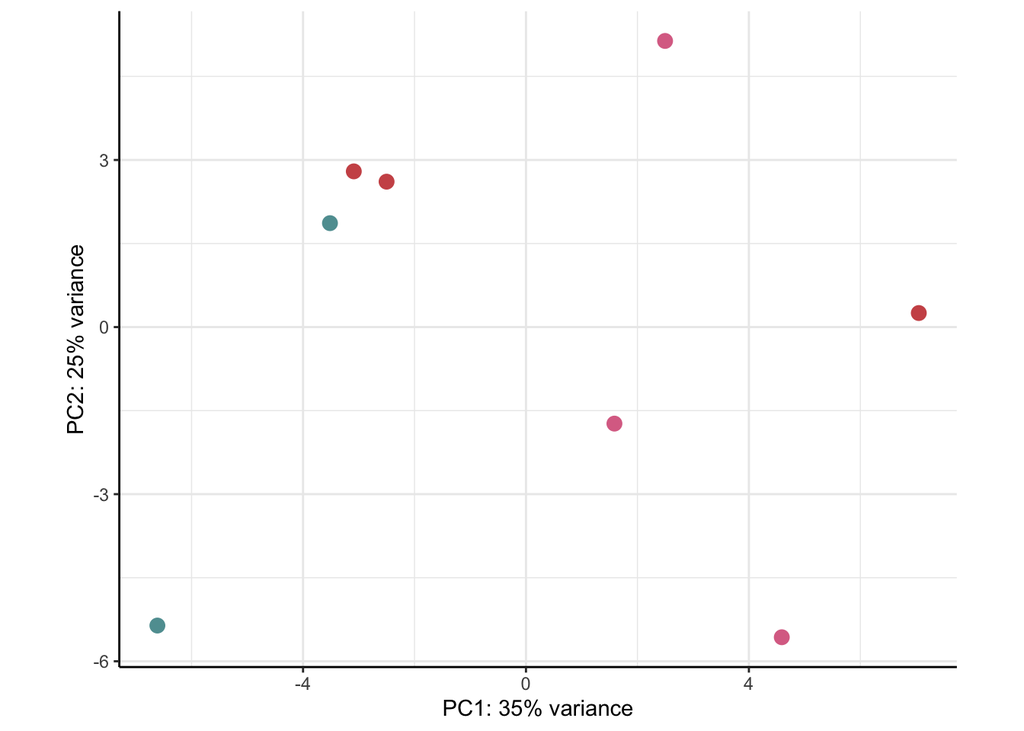

```r
gPCAdata_fe <- plotPCA(gvst_fe, intgroup = c("treatment"), returnData=TRUE)
percentVar_fe <- round(100*attr(gPCAdata_fe, "percentVar")) #plot PCA of samples with all data
fePCA <- ggplot(gPCAdata_fe, aes(PC1, PC2, color=treatment)) +
  geom_point(size=3) +
  xlab(paste0("PC1: ",percentVar_fe[1],"% variance")) +
  ylab(paste0("PC2: ",percentVar_fe[2],"% variance")) +
  scale_color_manual(labels = c("pH 7.8", "pH 7.6","pH 7.3"), values = c("amb"="cadetblue", "l"="palevioletred", "xl"="indianred3")) +
  coord_fixed() +
  theme_bw() + #Set background color
  theme(panel.border = element_blank(), # Set border
                     #panel.grid.major = element_blank(), #Set major gridlines
                     #panel.grid.minor = element_blank(), #Set minor gridlines
                     axis.line = element_line(colour = "black"), #Set axes color
        plot.background=element_blank()) + #Set the plot background
  theme(legend.position = ("none")); fePCA #set title attributes
```

#### Differential Gene Expression Analysis

##### Run DE analysis

Run differential expression test using a Wald model.

```r
DEG_fe <- DESeq(gdds_fe) #run differential expression test by group using the Wald model
```

Explore significant p-values for treatment_l_vs_amb, treatment_xl_vs_amb, and treatment_xl_vs_l

```r
DEG_fe.results.l_vs_amb <- results(DEG_fe, contrast= c("treatment","l","amb"))
head(DEG_fe.results.l_vs_amb)
```

```
## log2 fold change (MLE): treatment l vs amb
## Wald test p-value: treatment l vs amb
## DataFrame with 6 rows and 6 columns
##                     baseMean log2FoldChange     lfcSE       stat    pvalue
##                    <numeric>      <numeric> <numeric>  <numeric> <numeric>
## adi2mcaRNA17502_R0  426.2002     -0.1997023  0.260331 -0.7671095 0.4430164
## g47168              588.5927     -0.2769541  0.304659 -0.9090624 0.3633172
## g21716             1064.8235     -0.1952730  0.247695 -0.7883607 0.4304858
## g21714              216.8869      0.1072049  0.436727  0.2454736 0.8060898
## g21713               63.4975     -0.0562721  0.986743 -0.0570282 0.9545228
## g35549             4829.7552      0.4821803  0.239467  2.0135593 0.0440558
##                         padj
##                    <numeric>
## adi2mcaRNA17502_R0  0.997254
## g47168              0.997254
## g21716              0.997254
## g21714              0.997254
## g21713              0.997411
## g35549              0.954932
```

```r
sum(DEG_fe.results.l_vs_amb$padj < 0.05, na.rm=TRUE)
```

```
## [1] 0
```

```r
DEG_fe.results.xl_vs_amb <- results(DEG_fe, contrast= c("treatment","xl","amb"))
head(DEG_fe.results.xl_vs_amb)
```

```
## log2 fold change (MLE): treatment xl vs amb
## Wald test p-value: treatment xl vs amb
## DataFrame with 6 rows and 6 columns
##                     baseMean log2FoldChange     lfcSE       stat    pvalue
##                    <numeric>      <numeric> <numeric>  <numeric> <numeric>
## adi2mcaRNA17502_R0  426.2002     -0.0175631  0.259857 -0.0675876  0.946114
## g47168              588.5927     -0.1953320  0.304499 -0.6414860  0.521207
## g21716             1064.8235      0.0676020  0.247416  0.2732319  0.784675
## g21714              216.8869      0.1069955  0.436653  0.2450352  0.806429
## g21713               63.4975      0.0878458  0.986059  0.0890878  0.929012
## g35549             4829.7552      0.1593644  0.239526  0.6653316  0.505838
##                         padj
##                    <numeric>
## adi2mcaRNA17502_R0  0.999571
## g47168              0.999571
## g21716              0.999571
## g21714              0.999571
## g21713              0.999571
## g35549              0.999571
```

```r
sum(DEG_fe.results.xl_vs_amb$padj < 0.05, na.rm=TRUE) #How many adjusted p-values were less than 0.05?
```

```
## [1] 0
```

```r
DEG_fe.results.xl_vs_l <- results(DEG_fe, contrast= c("treatment","xl","l"))
head(DEG_fe.results.xl_vs_l)
```

```
## log2 fold change (MLE): treatment xl vs l
## Wald test p-value: treatment xl vs l
## DataFrame with 6 rows and 6 columns
##                     baseMean log2FoldChange     lfcSE         stat    pvalue
##                    <numeric>      <numeric> <numeric>    <numeric> <numeric>
## adi2mcaRNA17502_R0  426.2002     0.18213919  0.233093  0.781401075  0.434567
## g47168              588.5927     0.08162214  0.272928  0.299061222  0.764893
## g21716             1064.8235     0.26287494  0.221571  1.186413742  0.235459
## g21714              216.8869    -0.00020944  0.390384 -0.000536498  0.999572
## g21713               63.4975     0.14411793  0.882462  0.163313423  0.870272
## g35549             4829.7552    -0.32281585  0.214134 -1.507542928  0.131672
##                         padj
##                    <numeric>
## adi2mcaRNA17502_R0  0.999968
## g47168              0.999968
## g21716              0.999968
## g21714              0.999968
## g21713              0.999968
## g35549              0.999968
```

```r
sum(DEG_fe.results.xl_vs_l$padj < 0.05, na.rm=TRUE) #How many adjusted p-values were less than 0.05?
```

```
## [1] 0
```

*No genes were differentially expressed between treatments in the fertilized eggs.*

### Cleavage analysis

#### Construct DES2 dataset

##### Pre-filter gene counts

```r
#keep only cleaving embryos from treatmentinfo and count data
treatmentinfo_clvg <- filter(treatmentinfo, time_point=="Cleavage")
gcount_clvg <- gcount[, treatmentinfo_clvg$sample_id]

#create filter for the counts data according to the povera filter set earlier (0.875,5)
gfiltclvg <- genefilter(gcount_clvg, filt)

#identify genes to keep by count filter
gkeepclvg <- gcount_clvg[gfiltclvg,]

#identify gene lists
gn.keepclvg <- rownames(gkeepclvg)

#gene count data filtered in PoverA, P percent of the samples have counts over A
gcount_filt_clvg <- as.data.frame(gcount_clvg[which(rownames(gcount_clvg) %in% gn.keepclvg),])
head(gcount_filt_clvg)
```

```
##                    X153 X154 X155 X156 X157 X158 X159 X160
## g16988               94  251  144  278  145  103  144  219
## adi2mcaRNA17502_R0  429  846  514 1018  511  487  329  851
## g47168              929 1390  755  783  424  503  439  718
## g21716             1398 3335 2262 1874  976  823 1340 2644
## g21714              528 1517  955  903  390  320  482 1102
## g21713               69  244  209  255   69    0  101  182
```

```r
dim(gcount_filt_clvg)
```

```
## [1] 12837     8
```

#### Construct the DESeq dataset

```r
treatmentinfo_clvg$treatment <- factor(treatmentinfo_clvg$treatment, levels = c("amb","l", "xl"))
head(treatmentinfo_clvg)
```

```
##   sample_id time_point treatment extraction_batch
## 1      X153   Cleavage       amb                9
## 2      X154   Cleavage       amb                8
## 3      X155   Cleavage         l                9
## 4      X156   Cleavage        xl                8
## 5      X157   Cleavage        xl               11
## 6      X158   Cleavage         l                9
```

```r
#Set DESeq2 design
gdds_clvg <- DESeqDataSetFromMatrix(countData = gcount_filt_clvg,
                              colData = treatmentinfo_clvg,
                              design = ~treatment)
```

#### Visualize gene count data

We’re looking to see if the samples of the same pH treatments cluster

##### Log-transform the count data

First we are going to log-transform the data using a variance stabilizing transforamtion (vst). This is only for visualization purposes. Essentially, this is roughly similar to putting the data on the log2 scale. It will deal with the sampling variability of low counts by calculating within-group variability (if blind=FALSE). Importantly, it does not use the design to remove variation in the data, and so can be used to examine if there may be any variability do to technical factors such as extraction batch effects.

To do this we first need to calculate the size factors of our samples. This is a rough estimate of how many reads each sample contains compared to the others. In order to use VST (the faster log2 transforming process) to log-transform our data, the size factors need to be less than 4. Otherwise, there could be artefacts in our results.

```r
SF.gdds_clvg <- estimateSizeFactors( gdds_clvg ) #estimate size factors to determine if we can use vst  to transform our data. Size factors should be less than for to use vst
print(sizeFactors(SF.gdds_clvg)) #View size factors
```

```
##      X153      X154      X155      X156      X157      X158      X159      X160
## 0.9530261 1.8081958 1.2348067 1.3100733 0.6949191 0.6132778 0.7409538 1.2291788
```

Our size factors are all less than four, so we can use VST

```r
gvst_clvg <- vst(gdds_clvg, blind=FALSE) #apply a variance stabilizing transforamtion to minimize effects of small counts and normalize wrt library size
head(assay(gvst_clvg), 3) #view transformed gene count data
```

```
##                         X153      X154      X155      X156      X157      X158
## g16988              9.137640  9.278917  9.204121  9.487524  9.478484  9.367748
## adi2mcaRNA17502_R0  9.962479  9.990857  9.906213 10.401788 10.353634 10.420945
## g47168             10.608410 10.392313 10.198743 10.180298 10.197026 10.449738
##                         X159      X160
## g16988              9.441063  9.396847
## adi2mcaRNA17502_R0  9.952513 10.302010
## g47168             10.173257 10.161858
```

#### Principal component plot of samples

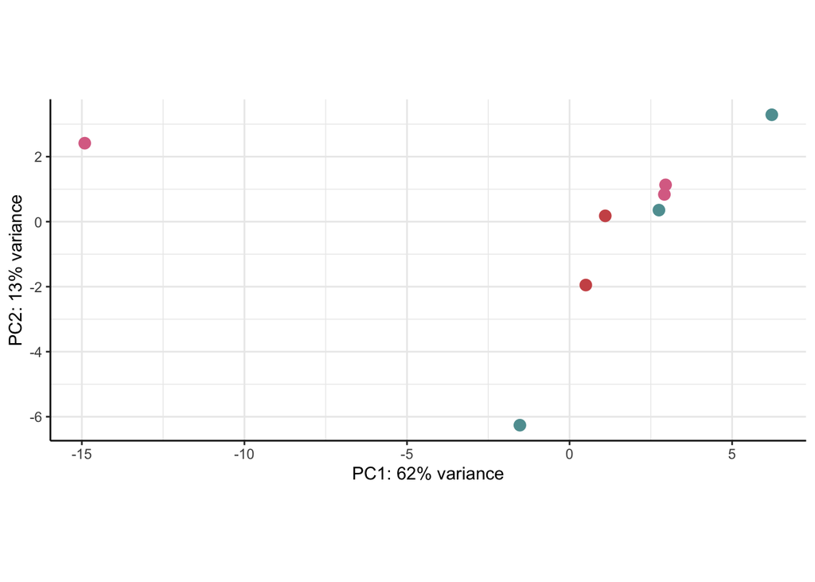

```r
gPCAdata_clvg <- plotPCA(gvst_clvg, intgroup = c("treatment"), returnData=TRUE)
percentVar_clvg <- round(100*attr(gPCAdata_clvg, "percentVar")) #plot PCA of samples with all data
clvgPCA <- ggplot(gPCAdata_clvg, aes(PC1, PC2, color=treatment)) +
  geom_point(size=3) +
  xlab(paste0("PC1: ",percentVar_clvg[1],"% variance")) +
  ylab(paste0("PC2: ",percentVar_clvg[2],"% variance")) +
  scale_color_manual(labels = c("pH 7.8", "pH 7.6","pH 7.3"), values = c("amb"="cadetblue", "l"="palevioletred", "xl"="indianred3")) +
  coord_fixed() +
  theme_bw() + #Set background color
  theme(panel.border = element_blank(), # Set border
                     #panel.grid.major = element_blank(), #Set major gridlines
                     #panel.grid.minor = element_blank(), #Set minor gridlines
                     axis.line = element_line(colour = "black"), #Set axes color
        plot.background=element_blank()) + #Set the plot background
  theme(legend.position = ("none")); clvgPCA #set title attributes
```

It doesn’t look like there is any clustering in the gene counts as a whole.

#### Differential Gene Expression Analysis

##### Run DE analysis

Run differential expression test using a Wald model.

```r
DEG_clvg <- DESeq(gdds_clvg) #run differential expression test by group using the Wald model
```

Explore significant p-values for treatment_l_vs_amb, treatment_xl_vs_amb, and treatment_xl_vs_l

```r
DEG_clvg.results.l_vs_amb <- results(DEG_clvg, contrast=c("treatment","l","amb"))
head(DEG_clvg.results.l_vs_amb)
```

```
## log2 fold change (MLE): treatment l vs amb
## Wald test p-value: treatment l vs amb
## DataFrame with 6 rows and 6 columns
##                     baseMean log2FoldChange     lfcSE       stat    pvalue
##                    <numeric>      <numeric> <numeric>  <numeric> <numeric>
## g16988               164.423      0.1014242  0.397474  0.2551720  0.798590
## adi2mcaRNA17502_R0   597.139      0.4787355  0.265804  1.8010820  0.071690
## g47168               694.944     -0.2164487  0.250058 -0.8655950  0.386712
## g21716              1659.946      0.0582307  0.204805  0.2843221  0.776164
## g21714               685.713      0.1022154  0.266402  0.3836880  0.701210
## g21713               119.364     -0.1125599  1.428313 -0.0788062  0.937187
##                         padj
##                    <numeric>
## g16988              0.999875
## adi2mcaRNA17502_R0  0.999875
## g47168              0.999875
## g21716              0.999875
## g21714              0.999875
## g21713              0.999875
```

```r
sum(DEG_clvg.results.l_vs_amb$padj < 0.05, na.rm=TRUE) #How many adjusted p-values were less than 0.05?
```

```
## [1] 0
```

```r
DEG_clvg.results.xl_vs_amb <- results(DEG_clvg, name="treatment_xl_vs_amb")
head(DEG_clvg.results.xl_vs_amb)
```

```
## log2 fold change (MLE): treatment xl vs amb
## Wald test p-value: treatment xl vs amb
## DataFrame with 6 rows and 6 columns
##                     baseMean log2FoldChange     lfcSE      stat    pvalue
##                    <numeric>      <numeric> <numeric> <numeric> <numeric>
## g16988               164.423       0.551696  0.442338  1.247228 0.2123138
## adi2mcaRNA17502_R0   597.139       0.735930  0.296601  2.481215 0.0130935
## g47168               694.944      -0.367738  0.280066 -1.313039 0.1891698
## g21716              1659.946      -0.267907  0.229369 -1.168015 0.2428006
## g21714               685.713      -0.123818  0.298342 -0.415018 0.6781285
## g21713               119.364       0.360169  1.596097  0.225656 0.8214690
##                         padj
##                    <numeric>
## g16988              0.999944
## adi2mcaRNA17502_R0  0.999944
## g47168              0.999944
## g21716              0.999944
## g21714              0.999944
## g21713              0.999944
```

```r
sum(DEG_clvg.results.xl_vs_amb$padj < 0.05, na.rm=TRUE) #How many adjusted p-values were less than 0.05?
```

```
## [1] 0
```

```r
DEG_clvg.results.xl_vs_l <- results(DEG_clvg, contrast= c("treatment","xl","l"))
head(DEG_clvg.results.xl_vs_l)
```

```
## log2 fold change (MLE): treatment xl vs l
## Wald test p-value: treatment xl vs l
## DataFrame with 6 rows and 6 columns
##                     baseMean log2FoldChange     lfcSE      stat    pvalue
##                    <numeric>      <numeric> <numeric> <numeric> <numeric>
## g16988               164.423       0.450272  0.442479  1.017611  0.308863
## adi2mcaRNA17502_R0   597.139       0.257194  0.296074  0.868682  0.385021
## g47168               694.944      -0.151289  0.280501 -0.539353  0.589643
## g21716              1659.946      -0.326137  0.229420 -1.421574  0.155150
## g21714               685.713      -0.226033  0.298386 -0.757517  0.448740
## g21713               119.364       0.472729  1.596457  0.296111  0.767145
##                         padj
##                    <numeric>
## g16988               0.99931
## adi2mcaRNA17502_R0   0.99931
## g47168               0.99931
## g21716               0.99931
## g21714               0.99931
## g21713               0.99931
```

```r
sum(DEG_clvg.results.xl_vs_l$padj < 0.05, na.rm=TRUE) #How many adjusted p-values were less than 0.05?
```

```
## [1] 0
```

*No genes were differentially expressed between treatments in the cleavage samples.*

### Prawn chip analysis

##### Pre-filter gene counts

Pre-filtering our dataset to reduce the memory size dataframe, increase the speed of the transformation and testing functions, and improve quality of statistical analysis by removing low-coverage counts. Removed counts could represent outliers in the data and removing these improves sensitivity of statistical tests. Here we will filter out the samples from time points where we only took ambient samples.. We will also apply a filter so only transcripts with low coverage using the PoverA filter described above (P=0.875, A=10).

```r
#keep only selected life stage from treatmentinfo and count data
treatmentinfo_pc <- filter(treatmentinfo, time_point=="Prawn_chip")
gcount_pc <- gcount[,treatmentinfo_pc$sample_id]

#create filter for the counts data
gfiltpc <- genefilter(gcount_pc, filt)

#identify genes to keep by count filter
gkeeppc <- gcount_pc[gfiltpc,]

#identify gene lists
gn.keeppc <- rownames(gkeeppc)

#gene count data filtered in PoverA, P percent of the samples have counts over A
gcount_filt_pc <- as.data.frame(gcount_pc[which(rownames(gcount_pc) %in% gn.keeppc),])
dim(gcount_filt_pc)
```

```
## [1] 16392     8
```

#### Construct the DESeq dataset

```r
treatmentinfo_pc$treatment <- factor(treatmentinfo_pc$treatment, levels = c("amb","l", "xl"))
```

```r
#Set DESeq2 design
gdds_pc <- DESeqDataSetFromMatrix(countData = gcount_filt_pc,
                              colData = treatmentinfo_pc,
                              design = ~treatment)
```

#### Visualize gene count data

We’re looking to see if the samples of the same pH treatments cluster

##### Log-transform the count data

Log-transform the data using a variance stabilizing transforamtion (vst) for visualization purposes, only. To do this we first need to calculate the size factors of our samples. This is a rough estimate of how many reads each sample contains compared to the others. In order to use VST (the faster log2 transforming process) to log-transform our data, the size factors need to be less than 4. Otherwise, there could be artefacts in our results.

```r
SF.gdds_pc <- estimateSizeFactors( gdds_pc ) #estimate size factors to determine if we can use vst  to transform our data. Size factors should be less than for to use vst
print(sizeFactors(SF.gdds_pc)) #View size factors
```

```
##      X162      X163      X164      X165      X166      X167      X168      X169
## 0.9042389 1.0286127 1.0566156 1.2546972 1.1346755 1.0511316 0.9336223 0.7768940
```

Our size factors are all less than 4 so we can use vst!

```r
gvst_pc <- vst(gdds_pc, blind=FALSE) #apply a variance stabilizing transforamtion to minimize effects of small counts and normalize wrt library size
head(assay(gvst_pc), 3) #view transformed gene count data
```

```
##                         X162      X163      X164      X165      X166      X167
## g16988              9.171545  9.245688  9.276147  9.226621  9.140986  9.471569
## adi2mcaRNA17502_R0  9.708092  9.767643  9.866000  9.600683  9.466397  9.884548
## g47168             11.361975 11.170653 11.321876 11.262376 11.030579 11.431872
##                         X168      X169
## g16988              9.701169  9.406113
## adi2mcaRNA17502_R0  9.780295  9.538677
## g47168             11.684318 11.091443
```

#### Principal component plot of samples

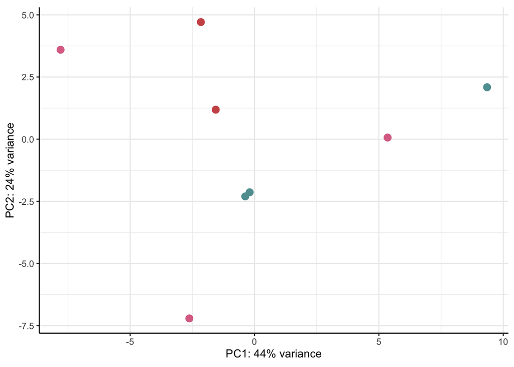

```r
gPCAdata_pc <- plotPCA(gvst_pc, intgroup = c("treatment"), returnData=TRUE)
percentVar_pc <- round(100*attr(gPCAdata_pc, "percentVar")) #plot PCA of samples with all data
pcPCA <- ggplot(gPCAdata_pc, aes(PC1, PC2, color=treatment)) +
  geom_point(size=3) +
  xlab(paste0("PC1: ",percentVar_pc[1],"% variance")) +
  ylab(paste0("PC2: ",percentVar_pc[2],"% variance")) +
  scale_color_manual(labels = c("pH 7.8", "pH 7.6","pH 7.3"), values = c("amb"="cadetblue", "l"="palevioletred", "xl"="indianred3")) +
  coord_fixed() +
    theme_bw() + #Set background color
  theme(panel.border = element_blank(), # Set border
                     #panel.grid.major = element_blank(), #Set major gridlines
                     #panel.grid.minor = element_blank(), #Set minor gridlines
                     axis.line = element_line(colour = "black"), #Set axes color
        plot.background=element_blank()) + #Set the plot background
  theme(legend.position = ("none")); pcPCA #set title attributes
```

It doesn’t look like there is much any clustering in the gene counts due to treatment as a whole.

#### Differential Gene Expression Analysis

##### Run DE analysis

Run differential expression test using a Wald model.

```r
DEG_pc <- DESeq(gdds_pc) #run difpcrential expression test by group using the Wald model
```

Explore significant p-values for treatment_l_vs_amb, treatment_xl_vs_amb, and treatment_xl_vs_l

```r
DEG_pc.results.l_vs_amb <- results(DEG_pc, contrast=c("treatment","l","amb"))
head(DEG_pc.results.l_vs_amb)
```

```
## log2 fold change (MLE): treatment l vs amb
## Wald test p-value: treatment l vs amb
## DataFrame with 6 rows and 6 columns
##                     baseMean log2FoldChange     lfcSE       stat    pvalue
##                    <numeric>      <numeric> <numeric>  <numeric> <numeric>
## g16988               288.412      0.1848984  0.285249  0.6481990  0.516856
## adi2mcaRNA17502_R0   459.741     -0.1237494  0.206034 -0.6006250  0.548090
## g47168              2120.348      0.0527841  0.176888  0.2984045  0.765394
## g21716              1419.017      0.0211483  0.177781  0.1189575  0.905309
## g21714               581.024      0.1305620  0.170799  0.7644190  0.444618
## g21713               837.839      0.0134468  0.142071  0.0946482  0.924594
##                         padj
##                    <numeric>
## g16988              0.998231
## adi2mcaRNA17502_R0  0.998231
## g47168              0.998231
## g21716              0.998231
## g21714              0.998231
## g21713              0.998231
```

```r
sum(DEG_pc.results.l_vs_amb$padj < 0.05, na.rm=TRUE) #How many adjusted p-values were less than 0.05?
```

```
## [1] 0
```

```r
DEG_pc.results.xl_vs_amb <- results(DEG_pc, name="treatment_xl_vs_amb")
head(DEG_pc.results.xl_vs_amb)
```

```
## log2 fold change (MLE): treatment xl vs amb
## Wald test p-value: treatment xl vs amb
## DataFrame with 6 rows and 6 columns
##                     baseMean log2FoldChange     lfcSE       stat    pvalue
##                    <numeric>      <numeric> <numeric>  <numeric> <numeric>
## g16988               288.412      0.0297711  0.319760  0.0931044  0.925821
## adi2mcaRNA17502_R0   459.741     -0.3758025  0.231696 -1.6219639  0.104811
## g47168              2120.348     -0.1741861  0.198047 -0.8795185  0.379120
## g21716              1419.017      0.1464035  0.198723  0.7367200  0.461293
## g21714               581.024      0.2028844  0.190949  1.0625067  0.288006
## g21713               837.839     -0.1988665  0.159690 -1.2453318  0.213010
##                         padj
##                    <numeric>
## g16988              0.999693
## adi2mcaRNA17502_R0  0.999693
## g47168              0.999693
## g21716              0.999693
## g21714              0.999693
## g21713              0.999693
```

```r
sum(DEG_pc.results.xl_vs_amb$padj < 0.05, na.rm=TRUE) #How many adjusted p-values were less than 0.05?
```

```
## [1] 0
```

```r
DEG_pc.results.xl_vs_l <- results(DEG_pc, contrast= c("treatment","xl","l"))
head(DEG_pc.results.xl_vs_l)
```

```
## log2 fold change (MLE): treatment xl vs l
## Wald test p-value: treatment xl vs l
## DataFrame with 6 rows and 6 columns
##                     baseMean log2FoldChange     lfcSE      stat    pvalue
##                    <numeric>      <numeric> <numeric> <numeric> <numeric>
## g16988               288.412     -0.1551273  0.319124 -0.486104  0.626894
## adi2mcaRNA17502_R0   459.741     -0.2520531  0.231823 -1.087265  0.276920
## g47168              2120.348     -0.2269701  0.197983 -1.146410  0.251626
## g21716              1419.017      0.1252552  0.198650  0.630531  0.528347
## g21714               581.024      0.0723224  0.190521  0.379603  0.704240
## g21713               837.839     -0.2123132  0.159557 -1.330642  0.183307
##                         padj
##                    <numeric>
## g16988              0.979408
## adi2mcaRNA17502_R0  0.929271
## g47168              0.917812
## g21716              0.973435
## g21714              0.980812
## g21713              0.894805
```

```r
sum(DEG_pc.results.xl_vs_l$padj < 0.05, na.rm=TRUE) #How many adjusted p-values were less than 0.05?
```

```
## [1] 0
```

*No genes were differentially expressed between treatments in the prawn chip samples.*

### Early gastrula analysis

##### Pre-filter gene counts

Pre-filtering our dataset to reduce the memory size dataframe, increase the speed of the transformation and testing functions, and improve quality of statistical analysis by removing low-coverage counts. Removed counts could represent outliers in the data and removing these improves sensitivity of statistical tests. Here we will filter out the samples from time points where we only took ambient samples. We will also apply a filter so only transcripts with low coverage using the PoverA filter described above (P=0.875, A=10).

```r
#keep only selected life stage from treatmentinfo and count data
treatmentinfo_gsa <- filter(treatmentinfo, time_point=="Early_gastrula")
gcount_gsa <- gcount[, treatmentinfo_gsa$sample_id]

#create filter for the counts data
gfiltgsa <- genefilter(gcount_gsa, filt)

#identify genes to keep by count filter
gkeepgsa <- gcount_gsa[gfiltgsa,]

#identify gene lists
gn.keepgsa <- rownames(gkeepgsa)

#gene count data filtered in PoverA, P percent of the samples have counts over A
gcount_filt_gsa <- as.data.frame(gcount_gsa[which(rownames(gcount_gsa) %in% gn.keepgsa),])
dim(gcount_filt_gsa)
```

```
## [1] 17669     8
```

#### Construct the DESeq dataset

```r
treatmentinfo_gsa$treatment <- factor(treatmentinfo_gsa$treatment, levels = c("amb","l", "xl"))
head(treatmentinfo_gsa)
```

```
##   sample_id     time_point treatment extraction_batch
## 1      X179 Early_gastrula       amb               10
## 2      X180 Early_gastrula       amb               11
## 3      X181 Early_gastrula         l                8
## 4      X182 Early_gastrula        xl                8
## 5      X183 Early_gastrula         l               12
## 6      X184 Early_gastrula       amb               12
```

```r
#Set DESeq2 design
gdds_gsa <- DESeqDataSetFromMatrix(countData = gcount_filt_gsa,
                              colData = treatmentinfo_gsa,
                              design = ~treatment)
```

#### Visualize gene count data

We’re looking to see if the samples of the same pH treatments cluster

##### Log-transform the count data

Log-transform the data using a variance stabilizing transforamtion (vst) for visualization purposes, only. To do this we first need to calculate the size factors of our samples. This is a rough estimate of how many reads each sample contains compared to the others. In order to use VST (the faster log2 transforming process) to log-transform our data, the size factors need to be less than 4. Otherwise, there could be artefacts in our results.

```r
SF.gdds_gsa <- estimateSizeFactors( gdds_gsa ) #estimate size factors to determine if we can use vst  to transform our data. Size factors should be less than for to use vst
print(sizeFactors(SF.gdds_gsa)) #View size factors
```

```
##      X179      X180      X181      X182      X183      X184      X185      X186
## 0.9580303 0.8058715 1.0082684 1.6894364 1.0882760 0.9102871 0.8655881 0.9348140
```

Our size factors are less than 4, so we can use vst!

```r
gvst_gsa <- vst(gdds_gsa, blind=FALSE) #apply a variance stabilizing transforamtion to minimize effects of small counts and normalize wrt library size
head(assay(gvst_gsa), 3) #view transformed gene count data
```

```
##                         X179      X180      X181      X182      X183      X184
## g16988              8.965696  8.905982  8.808907  8.897613  8.960469  8.963556
## adi2mcaRNA17502_R0  9.833205 10.434874  9.829844  9.869859  9.449406  9.894507
## g47168             11.268131 11.361261 11.206774 11.090668 11.234424 11.385134
##                         X185      X186
## g16988              9.118156  9.086339
## adi2mcaRNA17502_R0  9.879029  9.929258
## g47168             11.421311 11.262425
```

#### Principal component plot of samples

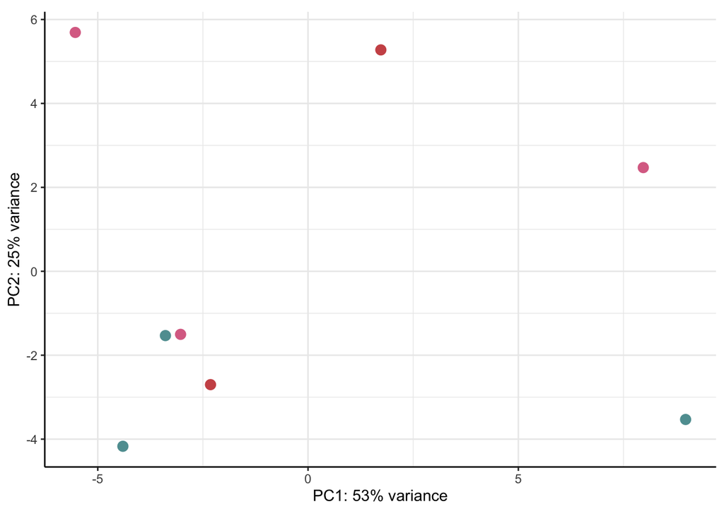

```r
gPCAdata_gsa <- plotPCA(gvst_gsa, intgroup = c("treatment"), returnData=TRUE)
percentVar_gsa <- round(100*attr(gPCAdata_gsa, "percentVar")) #plot PCA of samples with all data
gsaPCA <- ggplot(gPCAdata_gsa, aes(PC1, PC2, color=treatment)) +
  geom_point(size=3) +
  xlab(paste0("PC1: ",percentVar_gsa[1],"% variance")) +
  ylab(paste0("PC2: ",percentVar_gsa[2],"% variance")) +
  scale_color_manual(labels = c("pH 7.8", "pH 7.6","pH 7.3"), values = c("amb"="cadetblue", "l"="palevioletred", "xl"="indianred3")) +
  coord_fixed() +
    theme_bw() + #Set background color
  theme(panel.border = element_blank(), # Set border
                     #panel.grid.major = element_blank(), #Set major gridlines
                     #panel.grid.minor = element_blank(), #Set minor gridlines
                     axis.line = element_line(colour = "black"), #Set axes color
        plot.background=element_blank()) + #Set the plot background
  theme(legend.position = ("none")); gsaPCA #set title attributes
```

It doesn’t look like there is much any clustering in the gene counts as a whole.

#### Differential Gene Expression Analysis

##### Run DE analysis

Run differential expression test using a Wald model.

```r
DEG_gsa <- DESeq(gdds_gsa) #run difgsarential expression test by group using the Wald model
```

Explore significant p-values for treatment_l_vs_amb, treatment_xl_vs_amb, and treatment_xl_vs_l

```r
DEG_gsa.results.l_vs_amb <- results(DEG_gsa, contrast=c("treatment","l","amb"))
head(DEG_gsa.results.l_vs_amb)
```

```
## log2 fold change (MLE): treatment l vs amb
## Wald test p-value: treatment l vs amb
## DataFrame with 6 rows and 6 columns
##                     baseMean log2FoldChange     lfcSE      stat    pvalue
##                    <numeric>      <numeric> <numeric> <numeric> <numeric>
## g16988              197.7865      0.0509846  0.260423  0.195776 0.8447853
## adi2mcaRNA17502_R0  628.8586     -0.5171984  0.247727 -2.087775 0.0368181
## g47168             2132.7041     -0.0561860  0.142201 -0.395116 0.6927576
## g21716              627.5958     -0.3320186  0.189300 -1.753930 0.0794426
## g21714              503.7162     -0.1078899  0.200139 -0.539075 0.5898352
## g21715               21.5039     -0.5131854  0.624778 -0.821388 0.4114254
##                         padj
##                    <numeric>
## g16988              0.999831
## adi2mcaRNA17502_R0  0.999831
## g47168              0.999831
## g21716              0.999831
## g21714              0.999831
## g21715              0.999831
```

```r
sum(DEG_gsa.results.l_vs_amb$padj < 0.05, na.rm=TRUE) #How many adjusted p-values were less than 0.05?
```

```
## [1] 2
```

```r
gsa_DEGs.l_vs_amb <- as.data.frame(subset(DEG_gsa.results.l_vs_amb, padj<0.05))
gsa_DEGs.l_vs_amb$contrast <- as.factor(c("l_vs_amb"))
gsa_DEGs.l_vs_amb$gene_id <- rownames(gsa_DEGs.l_vs_amb)
rownames(gsa_DEGs.l_vs_amb) <- NULL
gsa_DEGs.l_vs_amb
```

```
##   baseMean log2FoldChange     lfcSE     stat       pvalue         padj contrast
## 1 555.3657       1.459355 0.2537235 5.751754 8.832216e-09 0.0001560564 l_vs_amb
## 2 427.5616       1.028716 0.2093816 4.913115 8.964080e-07 0.0079193160 l_vs_amb
##   gene_id
## 1  g66924
## 2  g30050
```

```r
DEG_gsa.results.xl_vs_amb <- results(DEG_gsa, name="treatment_xl_vs_amb")
head(DEG_gsa.results.xl_vs_amb)
```

```
## log2 fold change (MLE): treatment xl vs amb
## Wald test p-value: treatment xl vs amb
## DataFrame with 6 rows and 6 columns
##                     baseMean log2FoldChange     lfcSE       stat    pvalue
##                    <numeric>      <numeric> <numeric>  <numeric> <numeric>
## g16988              197.7865       0.104663  0.288894  0.3622899  0.717135
## adi2mcaRNA17502_R0  628.8586      -0.263056  0.275925 -0.9533610  0.340407
## g47168             2132.7041      -0.186962  0.158796 -1.1773715  0.239047
## g21716              627.5958      -0.202816  0.210569 -0.9631796  0.335457
## g21714              503.7162       0.015786  0.222466  0.0709594  0.943430
## g21715               21.5039       0.101344  0.678318  0.1494043  0.881235
##                         padj
##                    <numeric>
## g16988              0.999895
## adi2mcaRNA17502_R0  0.999895
## g47168              0.999895
## g21716              0.999895
## g21714              0.999895
## g21715              0.999895
```

```r
sum(DEG_gsa.results.xl_vs_amb$padj < 0.05, na.rm=TRUE)
```

```
## [1] 0
```

```r
DEG_gsa.results.xl_vs_l <- results(DEG_gsa, contrast= c("treatment","xl","l"))
head(DEG_gsa.results.xl_vs_l)
```

```
## log2 fold change (MLE): treatment xl vs l
## Wald test p-value: treatment xl vs l
## DataFrame with 6 rows and 6 columns
##                     baseMean log2FoldChange     lfcSE      stat    pvalue
##                    <numeric>      <numeric> <numeric> <numeric> <numeric>
## g16988              197.7865      0.0536787  0.288004  0.186381  0.852146
## adi2mcaRNA17502_R0  628.8586      0.2541426  0.276490  0.919175  0.358004
## g47168             2132.7041     -0.1307756  0.158732 -0.823878  0.410009
## g21716              627.5958      0.1292029  0.210939  0.612515  0.540197
## g21714              503.7162      0.1236759  0.222385  0.556134  0.578119
## g21715               21.5039      0.6145290  0.685371  0.896637  0.369913
##                         padj
##                    <numeric>
## g16988              0.999862
## adi2mcaRNA17502_R0  0.999862
## g47168              0.999862
## g21716              0.999862
## g21714              0.999862
## g21715              0.999862
```

```r
sum(DEG_gsa.results.xl_vs_l$padj < 0.05, na.rm=TRUE) #How many adjusted p-values were less than 0.05?
```

```
## [1] 0
```

*There are two differentially-expressed genes between the low and ambient treatments at the early gastrula stage, but no differentially-expressed genes between the other comparisons.*

In the annotation file, there were no significant hits to gene_id g66924, but gene_id g30050 hit a **Stylophora pistillata** Proline-rich AKT1 substrate 1 sequence available in [Uniprot](https://www.uniprot.org/uniparc/UPI0010FCC89D). According to the [PFAM entry](https://pfam.xfam.org/family/PF15798), AKT signalling in involved in the regulation of apoptosis in response to cellular stress.

## Planula analysis

##### Pre-filter gene counts

Pre-filtering our dataset to reduce the memory size dataframe, increase the speed of the transformation and testing functions, and improve quality of statistical analysis by removing low-coverage counts. Removed counts could represent outliers in the data and removing these improves sensitivity of statistical tests. Here we will filter out the samples from time points where we only took ambient samples.. We will also apply a filter so only transcripts with low coverage using the PoverA filter described above (P=0.875, A=10).

```r
#keep only selected life stage from treatmentinfo and count data
treatmentinfo_pln <- filter(treatmentinfo, time_point=="Planula")
gcount_pln <- gcount[,treatmentinfo_pln$sample_id]

#create filter for the counts data
gfiltpln <- genefilter(gcount_pln, filt)
#identify genes to keep by count filter
gkeeppln <- gcount_pln[gfiltpln,]
#identify gene lists
gn.keeppln <- rownames(gkeeppln)
#gene count data filtered in PoverA, P percent of the samples have counts over A
gcount_filt_pln <- as.data.frame(gcount_pln[which(rownames(gcount_pln) %in% gn.keeppln),])
dim(gcount_filt_pln)
```

```
## [1] 23225     9
```

#### Construct the DESeq dataset

```r
treatmentinfo_pln$treatment <- factor(treatmentinfo_pln$treatment, levels = c("amb","l", "xl"))
head(treatmentinfo_pln)
```

```
##   sample_id time_point treatment extraction_batch
## 1      X359    Planula       amb                5
## 2      X361    Planula       amb                7
## 3      X363    Planula        xl                2
## 4      X365    Planula        xl                7
## 5      X367    Planula        xl                3
## 6      X371    Planula         l                4
```

```r
head(gcount_filt_pln)
```

```
##                    X359 X361 X363 X365 X367 X371 X373 X375 X379
## g16981               28   28   33  100   16   81   24  180   30
## g16988              156  134  194  132  141  225   77  110  162
## adi2mcaRNA17502_R0 3515 3373 2740 1936 1913 2225 2084 2522 1494
## g47168              893  946 1134  843  824  926  594  835  748
## g21716              524  567  568  696  452  693  559  338  785
## g21717               46   49   49   70   25   20   21   33   44
```

```r
#Set DESeq2 design
gdds_pln <- DESeqDataSetFromMatrix(countData = gcount_filt_pln,
                              colData = treatmentinfo_pln,
                              design = ~treatment)
```

#### Visualize gene count data

We’re looking to see if the samples of the same pH treatments cluster

##### Log-transform the count data

Log-transform the data using a variance stabilizing transforamtion (vst) for visualization purposes, only. To do this we first need to calculate the size factors of our samples. This is a rough estimate of how many reads each sample contains compared to the others. In order to use VST (the faster log2 transforming process) to log-transform our data, the size factors need to be less than 4. Otherwise, there could be artefacts in our results.

```r
SF.gdds_pln <- estimateSizeFactors( gdds_pln ) #estimate size factors to determine if we can use vst  to transform our data. Size factors should be less than for to use vst
print(sizeFactors(SF.gdds_pln)) #View size factors
```

```
##      X359      X361      X363      X365      X367      X371      X373      X375
## 1.1246550 1.0716188 1.2451158 0.9968242 0.9786569 1.0405345 0.7790187 0.8947957
##      X379
## 1.0133279
```

Our size factors are all less than 4, so we can use VST!

```r
gvst_pln <- vst(gdds_pln, blind=FALSE) #apply a variance stabilizing transformation to minimize effects of small counts and normalize wrt library size
head(assay(gvst_pln), 3) #view transformed gene count data
```

```
##                         X359      X361      X363      X365      X367      X371
## g16981              7.486045  7.502188  7.507019  8.129774  7.360150  7.981463
## g16988              8.342911  8.271708  8.426147  8.310704  8.369686  8.680698
## adi2mcaRNA17502_R0 11.708463 11.718000 11.240976 11.077652 11.086028 11.203285
##                         X373      X375      X379
## g16981              7.560089  8.622034  7.545682
## g16988              8.120668  8.260288  8.445062
## adi2mcaRNA17502_R0 11.499711 11.569521 10.724352
```

#### Principal component plot of samples

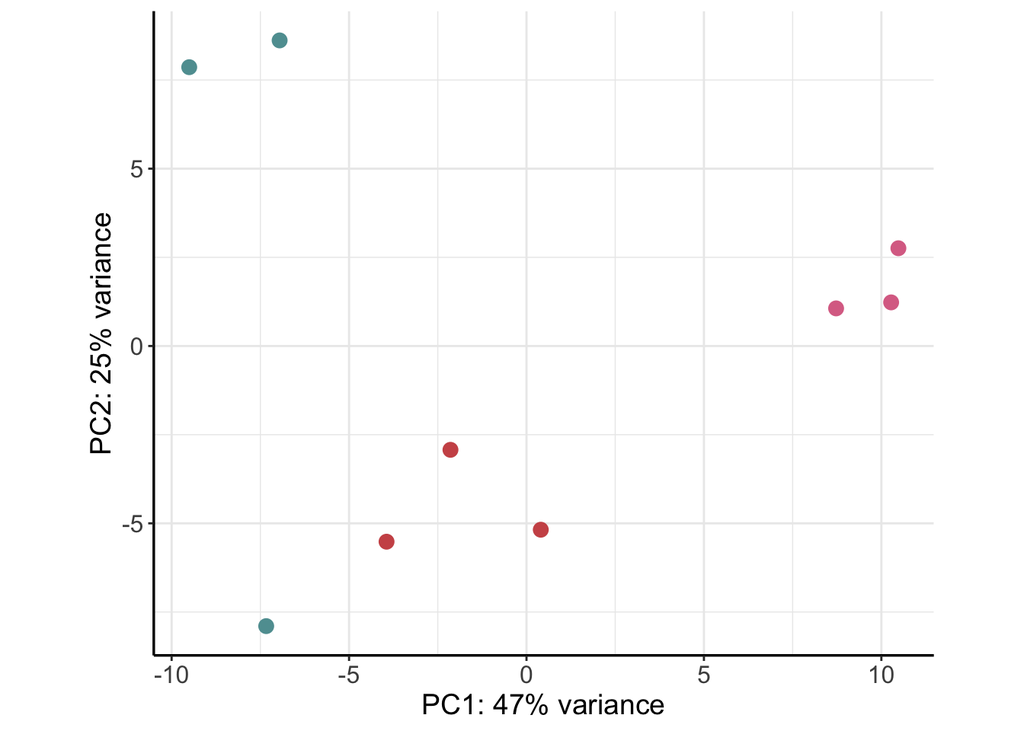

```r
gPCAdata_pln <- plotPCA(gvst_pln, intgroup = c("treatment"), returnData=TRUE)
percentVar_pln <- round(100*attr(gPCAdata_pln, "percentVar")) #plot PCA of samples with all data
plnPCA <- ggplot(gPCAdata_pln, aes(PC1, PC2, color=treatment)) +
  geom_point(size=3) +
  xlab(paste0("PC1: ",percentVar_pln[1],"% variance")) +
  ylab(paste0("PC2: ",percentVar_pln[2],"% variance")) +
  scale_color_manual(labels = c("pH 7.8", "pH 7.6","pH 7.3"), values = c("amb"="cadetblue", "l"="palevioletred", "xl"="indianred3")) +
  coord_fixed() +
  theme_bw() + #Set background color
  theme(panel.border = element_blank(), # Set border
                     #panel.grid.major = element_blank(), #Set major gridlines
                     #panel.grid.minor = element_blank(), #Set minor gridlines
                     axis.line = element_line(colour = "black", size = 0.6), #Set axes color
        plot.background=element_blank(), #Set the plot background
        legend.position = ("none"),
        axis.title = element_text(size = 14), #Axis title size
        axis.text = element_text(size = 12)) ; plnPCA #Axis text size; view plot
```

```r
ggsave(file = "4-Differential-Gene-Expression-Analysis/Output/Fig2-planula-PCA.png", plnPCA, width = 7.5/2, height = 11/2, units = "in")
```

There appears to be clustering by treatment, especially on the PC1 axis.

#### Differential Gene Expression Analysis

##### Run DE analysis

Run differential expression test using a Wald model.

```r
DEG_pln <- DESeq(gdds_pln) #run differential expression test by group using the Wald model
```

Explore significant p-values for treatment_l_vs_amb, treatment_xl_vs_amb, and treatment_xl_vs_l

```r
DEG_pln.results.l_vs_amb <- results(DEG_pln, contrast=c("treatment","l","amb"))
summary(DEG_pln.results.l_vs_amb) #view results summary
```

```
##
## out of 23225 with nonzero total read count
## adjusted p-value < 0.1
## LFC > 0 (up)       : 2603, 11%
## LFC < 0 (down)     : 2080, 9%
## outliers [1]       : 0, 0%
## low counts [2]     : 1802, 7.8%
## (mean count < 27)
## [1] see 'cooksCutoff' argument of ?results
## [2] see 'independentFiltering' argument of ?results
```

```r
sum(DEG_pln.results.l_vs_amb$padj < 0.05, na.rm=TRUE) #How many adjusted p-values were less than 0.05?
```

```
## [1] 3568
```

```r
pln_DEGs.l_vs_amb <- as.data.frame(subset(DEG_pln.results.l_vs_amb, padj<0.05))
pln.results.ordered.l_vs_amb <- order(pln_DEGs.l_vs_amb$padj) #Order p-values by smallest value first
pln_DEGs.l_vs_amb$contrast <- as.factor(c("l_vs_amb"))
pln_DEGs.l_vs_amb$gene_id  <- rownames(pln_DEGs.l_vs_amb)
rownames(pln_DEGs.l_vs_amb) <- NULL
write.csv(pln_DEGs.l_vs_amb, "4-Differential-Gene-Expression-Analysis/Output/pln_DEGs_l_vs_amb.csv")

DEG_pln.results.xl_vs_amb <- results(DEG_pln, contrast=c("treatment","xl","amb"))
summary(DEG_pln.results.xl_vs_amb) #view results summary
```

```
##
## out of 23225 with nonzero total read count
## adjusted p-value < 0.1
## LFC > 0 (up)       : 389, 1.7%
## LFC < 0 (down)     : 178, 0.77%
## outliers [1]       : 0, 0%
## low counts [2]     : 2252, 9.7%
## (mean count < 31)
## [1] see 'cooksCutoff' argument of ?results
## [2] see 'independentFiltering' argument of ?results
```

```r
sum(DEG_pln.results.xl_vs_amb$padj < 0.05, na.rm=TRUE) #How many adjusted p-values were less than 0.05?
```

```
## [1] 391
```

```r
pln_DEGs.xl_vs_amb <- as.data.frame(subset(DEG_pln.results.xl_vs_amb, padj<0.05))
pln.results.ordered.xl_vs_amb <- order(pln_DEGs.xl_vs_amb$padj) #Order p-values by smallest value first
pln_DEGs.xl_vs_amb$contrast <- as.factor(c("xl_vs_amb"))
pln_DEGs.xl_vs_amb$gene_id  <- rownames(pln_DEGs.xl_vs_amb)
rownames(pln_DEGs.xl_vs_amb) <- NULL
write.csv(pln_DEGs.xl_vs_amb, "4-Differential-Gene-Expression-Analysis/Output/pln_DEGs_xl_vs_amb.csv")

DEG_pln.results.xl_vs_l <- results(DEG_pln, contrast=c("treatment","xl","l"))
summary(DEG_pln.results.xl_vs_l) #view results summary
```

```
##
## out of 23225 with nonzero total read count
## adjusted p-value < 0.1
## LFC > 0 (up)       : 984, 4.2%
## LFC < 0 (down)     : 1316, 5.7%
## outliers [1]       : 0, 0%
## low counts [2]     : 4053, 17%
## (mean count < 47)
## [1] see 'cooksCutoff' argument of ?results
## [2] see 'independentFiltering' argument of ?results
```

```r
sum(DEG_pln.results.xl_vs_l$padj < 0.05, na.rm=TRUE) #How many adjusted p-values were less than 0.05?
```

```
## [1] 1447
```

```r
pln_DEGs.xl_vs_l <- as.data.frame(subset(DEG_pln.results.xl_vs_l, padj<0.05))
pln.results.ordered.xl_vs_l <- order(pln_DEGs.xl_vs_l$padj) #Order p-values by smallest value first
pln_DEGs.xl_vs_l$contrast <- as.factor(c("xl_vs_l"))
pln_DEGs.xl_vs_l$gene_id  <- rownames(pln_DEGs.xl_vs_l)
rownames(pln_DEGs.xl_vs_l) <- NULL
write.csv(pln_DEGs.xl_vs_l, "4-Differential-Gene-Expression-Analysis/Output/pln_DEGs_xl_vs_l.csv")

pln_DEGs_all <- bind_rows(pln_DEGs.l_vs_amb, pln_DEGs.xl_vs_amb, pln_DEGs.xl_vs_l)
```

#### Visualize differentially-expressed genes

##### Subset and Log-transform the count data

Subset the gene count matrix by the list of DEGs

```r
pln_DEGlist <- gdds_pln[pln_DEGs_all$gene_id,]
```

We know from before that our size factors are all less than 4, so we can use VST!

```r
pln_DEGvst <- vst(pln_DEGlist, blind=FALSE, nsub = nrow(counts(pln_DEGlist))) #apply a variance stabilizing transforamtion to minimize efplncts of small counts and normalize wrt library size
head(assay(pln_DEGvst)) #view transformed gene count data
```

```
##                         X359      X361      X363      X365      X367      X371
## adi2mcaRNA17502_R0 11.827009 11.776735 11.277730 11.070763 11.077829 11.058227
## g21716              9.487123  9.574918  9.402857  9.824705  9.380276  9.655685
## g21714              8.596284  8.575499  8.544874  8.522243  8.517989  8.655340
## g35549             13.036750 12.845595 12.970085 12.541598 12.962914 12.370857
## g50130              9.423674  9.469218  8.745226  8.250603  8.468387  8.040829
## g7652              10.373189 10.379231 10.640493 10.638174 10.584373 10.669674
##                         X373      X375      X379
## adi2mcaRNA17502_R0 11.371148 11.677541 10.557867
## g21716              9.753649  9.265513  9.797588
## g21714              8.845832  8.278054  8.513313
## g35549             12.413949 13.283472 12.274606
## g50130              7.967318  8.573905  7.939399
## g7652              10.598973 10.382348 10.867853
```

```r
dim(assay(pln_DEGvst))
```

```
## [1] 5406    9
```

Make a matrix for computing similarity

```r
matpln <- assay(pln_DEGvst)#[pln_topVarGenes, ] #make an expression object
matpln <- matpln - rowMeans(matpln) #difference in expression compared to average across all samples
```

### Compute the optimal number of clusters for plotting

Find the optimum number of clusters using 30 indexes with the NbClust() package. This took about 45 minutes to run, so it is commented out. Screenshots of the output are provided below.

```r
# nb <- NbClust(matpln, distance = "euclidean", min.nc = 2,
#         max.nc = 10, method = "kmeans")
#
# fviz_nbclust(nb)
```

*The optimal number of clusters is 2*.

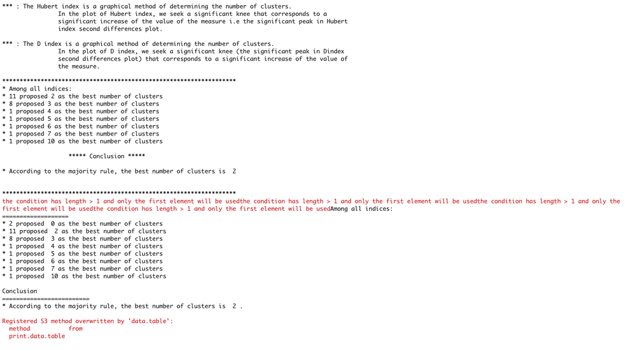

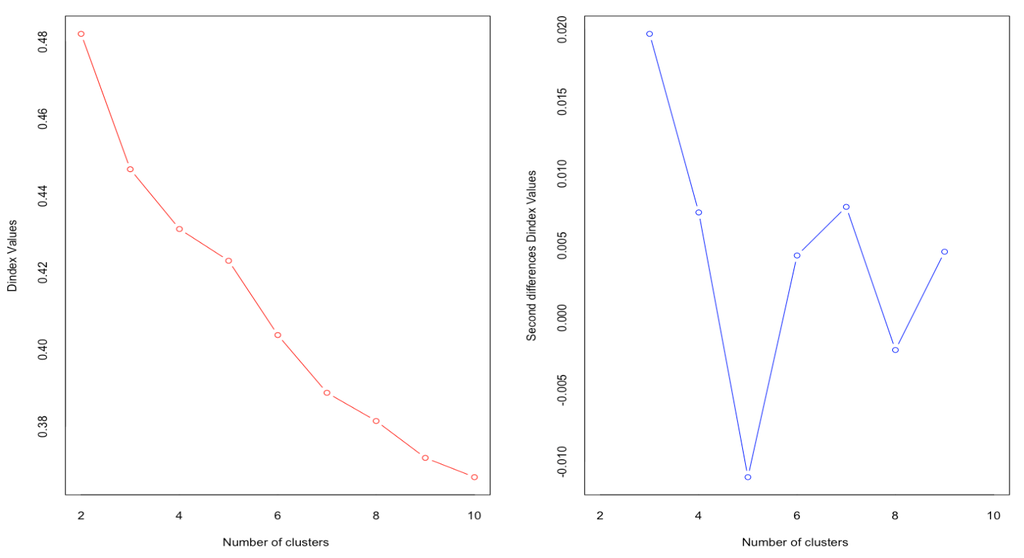

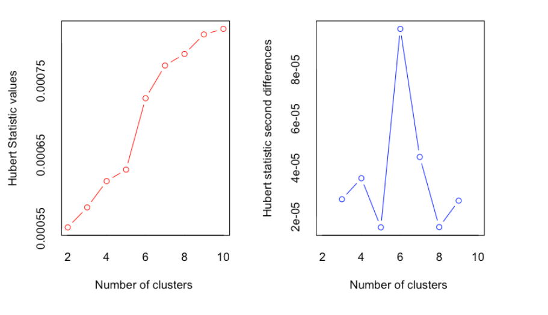

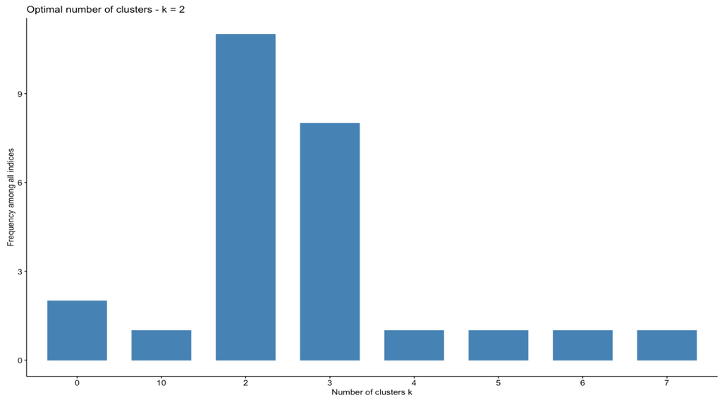

Get and save clustering results with DESeq2 results

```r
# calc.kmeans <- kmeans(matpln, 2)
# cluster_res <- data.frame(gene_id = names(calc.kmeans$cluster), cluster = calc.kmeans$cluster)
#
# pln_DEGs_all <- merge(pln_DEGs_all, cluster_res, by = "gene_id")
# write.csv(pln_DEGs_all, file="4-Differential-Gene-Expression-Analysis/Output/pln_DEGs_all.csv")
```

#### Plot a heatmap of differentially-expressed genes

[output not shown]

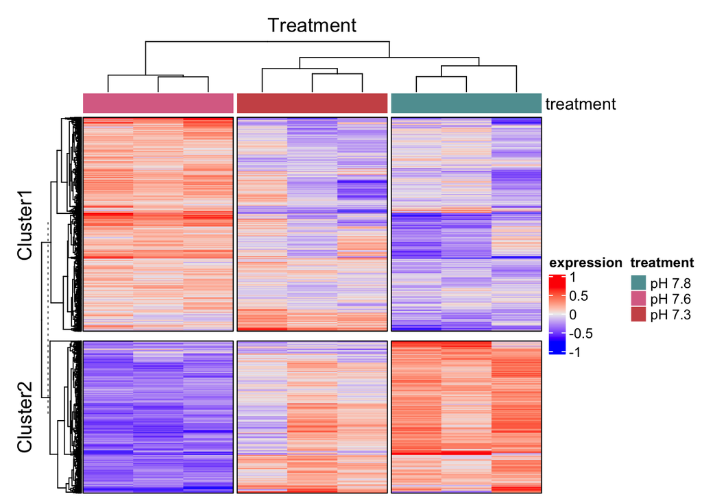

```r
pln_DEGs_all_clust <- read.csv("4-Differential-Gene-Expression-Analysis/Output/pln_DEGs_all.csv", header = TRUE, sep = ",")[,-c(1)]
pln_DEGs_all_clust <- subset(pln_DEGs_all_clust, select = c(gene_id, cluster))

#Prepare annotations
hm_ann_row <- unique(pln_DEGs_all_clust)
rownames(hm_ann_row) <- hm_ann_row$gene_id
hm_ann_row <- subset(hm_ann_row, select=cluster)
hm_ann_row$cluster <- gsub(1,"Cluster1",hm_ann_row$cluster)
hm_ann_row$cluster <- gsub(2,"Cluster2",hm_ann_row$cluster)
hm_ann_row <- as.matrix(hm_ann_row[rownames(matpln),])

hmTreatment <- colData(pln_DEGvst)[c("treatment")]

hmTreatment$treatment <- gsub("amb", "pH 7.8", hmTreatment$treatment) #replace AMB, l, and xl with pH 7.8, pH 7.6, and pH 7.3 for plotting
hmTreatment$treatment <- gsub("xl", "pH 7.3", hmTreatment$treatment) #replace AMB, l, and xl with pH 7.8, pH 7.6, and pH 7.3 for plotting
hmTreatment$treatment <- gsub("l", "pH 7.6", hmTreatment$treatment) #replace AMB, l, and xl with pH 7.8, pH 7.6, and pH 7.3 for plotting
hmTreatment$treatment <- factor(hmTreatment$treatment, levels=c("pH 7.8", "pH 7.6", "pH 7.3"))

hm_ann_col <- HeatmapAnnotation(df=hmTreatment, col = list(treatment=c("pH 7.8" ="cadetblue", "pH 7.6" ="palevioletred", "pH 7.3"  ="indianred3"))) #make dataframe for column naming

pln_DEGheatmap <-  Heatmap(matpln, column_title = "Treatment",
        name = "expression",
        show_row_names = FALSE, top_annotation = hm_ann_col, show_column_names = FALSE, row_dend_side = "left" ,
        column_split = 3, column_dend_height = unit(0.5, "in"),
        km = 2, row_km_repeats = 100, row_title = c("Cluster1", "Cluster2"),
        row_gap = unit(2.5, "mm"), border = TRUE,
        column_names_gp =  gpar(fontsize = 10)); pln_DEGheatmap
```

```r
png(file = "4-Differential-Gene-Expression-Analysis/Output/OA-PLN_DEGheatmap.png")
pln_DEGheatmap
dev.off()
```

### Venn Diagram of pairwise comparisons DEGs in Planula

```r
pln_l_vs_amb_venn <- as.data.frame(pln_DEGs.l_vs_amb$gene_id)
colnames(pln_l_vs_amb_venn) <- c("gene_id")
pln_l_vs_amb_venn$contrast <- as.character(c("Low vs Ambient"))
head(pln_l_vs_amb_venn)
```

```
##              gene_id       contrast
## 1 adi2mcaRNA17502_R0 Low vs Ambient
## 2             g21716 Low vs Ambient
## 3             g21714 Low vs Ambient
## 4             g35549 Low vs Ambient
## 5             g50130 Low vs Ambient
## 6              g7652 Low vs Ambient
```

```r
pln_xl_vs_amb_venn <- as.data.frame(pln_DEGs.xl_vs_amb$gene_id)
colnames(pln_xl_vs_amb_venn) <- c("gene_id")
pln_xl_vs_amb_venn$contrast <- as.character(c("Extreme Low vs Ambient"))
head(pln_xl_vs_amb_venn)
```

```
##              gene_id               contrast
## 1 adi2mcaRNA17502_R0 Extreme Low vs Ambient
## 2             g50130 Extreme Low vs Ambient
## 3  adi2mcaRNA3536_R0 Extreme Low vs Ambient
## 4             g31698 Extreme Low vs Ambient
## 5             g36478 Extreme Low vs Ambient
## 6              g5417 Extreme Low vs Ambient
```

```r
pln_xl_vs_l_venn <- as.data.frame(pln_DEGs.xl_vs_l$gene_id)
colnames(pln_xl_vs_l_venn) <- c("gene_id")
pln_xl_vs_l_venn$contrast <- as.character(c("Extreme Low vs Low"))
head(pln_xl_vs_l_venn)
```

```
##   gene_id           contrast
## 1  g50130 Extreme Low vs Low
## 2  g39880 Extreme Low vs Low
## 3  g41941 Extreme Low vs Low
## 4  g41942 Extreme Low vs Low
## 5  g33594 Extreme Low vs Low
## 6  g38027 Extreme Low vs Low
```

```r
pln_DEGs_all_venn <- bind_rows(pln_l_vs_amb_venn, pln_xl_vs_amb_venn, pln_xl_vs_l_venn)

# Chart
futile.logger::flog.threshold(futile.logger::ERROR, name = "VennDiagramLogger") #suppress log file generation
```

```r
venn.diagram(
       x = list(
    pln_DEGs_all_venn %>% filter(contrast=="Low vs Ambient") %>% subset(select=gene_id) %>% unlist() ,
    pln_DEGs_all_venn %>% filter(contrast=="Extreme Low vs Ambient") %>% subset(select=gene_id) %>% unlist() ,
    pln_DEGs_all_venn %>% filter(contrast=="Extreme Low vs Low") %>% subset(select=gene_id) %>% unlist()
    ),
  category.names = c("pH 7.6 vs pH 7.8" , "pH 7.3 vs pH 7.8" , "pH 7.3 vs pH 7.6"),
        filename = '4-Differential-Gene-Expression-Analysis/Output/venn_OA_pln_DEGs.png',
  output=TRUE,

        # Output features
        imagetype="png" ,
        height = 700 ,
        width = 700 ,
        resolution = 300,
        compression = "lzw",
        lwd = 0.75, #line width

        # Numbers
        cex = 0.5,
        fontface = "bold",
        fontfamily = "sans",

        # Set names
        cat.cex = 0.5,
        cat.fontface = "bold",
        cat.default.pos = "outer",
        cat.pos = c(-27, 18, 135),
        cat.dist = c(0.055, 0.055, 0.085),
        cat.fontfamily = "sans",
        rotation = 1
)
```

```
## [1] 1
```

Put together PCA plots for final and supplementary figures

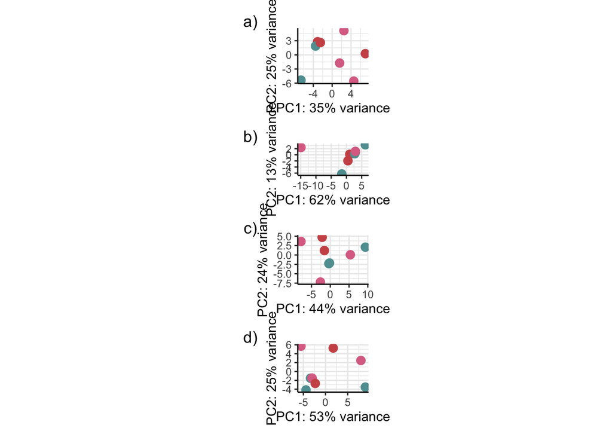

```r
SFigX <- fePCA / clvgPCA / pcPCA / gsaPCA + plot_annotation(tag_levels = "a", tag_suffix = ")"); SFigX
```

```r
ggsave(file = "4-Differential-Gene-Expression-Analysis/Output/SFig-fe2gsa-PCA.png", SFigX, width = 7.5, height = 11, units = "in")
# Fig3 <- allgenesfilt_PCA / plnPCA + plot_annotation(tag_levels = "a", tag_suffix = ")") #Must have allgenesfilt_PCA from WGCNA script in environment
# ggsave(file = "Final_figures/Fig3.png", Fig3, width = 7.5, height = 9, units = "in")
```